# Age-smooth k-grid evaluation

Convergence, age curves, brms smooth-term comparison, vs strong RE, fitting time

Author

Affiliation

Chen Zhan

SAiGENCI, The University of Adelaide

Published

03 Aug 2026

Abstract

Evaluation of continuous-age thin-plate smooth fits on healthy V1_nk samples (`disease_groups_altered == "Normal"`) for four TIMES biomarkers (SPON2, ZFP36L2, ZFP36, VIM) and smooth basis sizes k ∈ {3,4,5}. We report HMC convergence, blood/liver age curves, an explicit comparison with `brms::conditional_smooths()`, predict/linpred compatibility (needed for comprehensive μ), comprehensive healthy liver baseline mean/SD against the strong-HMC correlated RE (simple shape) fits, and wall-clock fitting times from the `formula_bench` targets pipeline (age-smooth vs RE formulas across chain × CPU settings).

# Motivation

Age-smooth models replace categorical `age_decade` with

`s(age_days_scaled, by = tissue_sex, bs = "tp", k, m = 1)`

on **healthy** rows only. This report asks:

1. **Convergence** — does HMC reliability depend on k?
2. **Age curves** — how do blood / liver log-mean trajectories look by k, and how do they differ from `brms::conditional_smooths()`?
3. **Predict API** — do `posterior_linpred` / `posterior_predict` work on these objects (required for comprehensive μ)?
4. **vs strong RE** — how do comprehensive liver baseline μ and SD compare to the long-run correlated RE (simple shape) fits?
5. **Fitting time** — how does wall-clock HMC time compare across formulas (age-smooth k vs RE) and chain × CPU settings from the `formula_bench` targets pipeline?

| Model | Data | Age | MCMC |
| --- | --- | --- | --- |
| Age-smooth k=3/4/5 | Normal only (n≈2905) | continuous smooth | 4×400/900, control=NULL |
| Strong RE (report §4) | all disease (n≈3226) | age_decade FE/RE | 4×1500/3000, δ=0.95 |
| formula_bench (§5) | Normal only (n=2905) | smooth or age_decade | 2/4 chains × 400/900 |

# Library setup

```r
suppressPackageStartupMessages({
  library(tibble)
  library(tidyr)
  library(dplyr)
  library(readr)
  library(ggplot2)
  library(forcats)
  library(scales)
  library(glue)
  library(stringr)
  library(posterior)
  library(brms)
})

source(file.path(params$case_dir, "R", "re_vs_interaction_helpers.R"))
source(file.path(params$case_dir, "R", "fit_convergence_helpers.R"))
source(file.path(params$case_dir, "R", "age_smooth_helpers.R"))

theme_set(theme_minimal(base_size = 11))

genes <- pilot_biomarker_genes()
ks <- age_smooth_ks_default()

k_colours <- c(`3` = "#4DBBD5", `4` = "#E64B35", `5` = "#3C5488")
model_colours <- c(
  `RE HMC (simple)` = "#7A7A7A",
  `Age-smooth k=3` = "#4DBBD5",
  `Age-smooth k=4` = "#E64B35",
  `Age-smooth k=5` = "#3C5488"
)
gate_colours <- c(PASS = "#2D8B57", WARN = "#E08A2E", FAIL = "#C23B4A")
setting_colours <- c(
  `2×8 (4 thr)` = "#00A087",
  `4×8 (2 thr)` = "#E64B35",
  `4×16 (4 thr)` = "#3C5488"
)
```

# Fit inventory

```r
inv <- age_smooth_inventory(params$smooth_out_dir, genes = genes, ks = ks)
inv |>
  transmute(
    gene, k, model,
    status = if_else(available, "OK", "MISSING"),
    file = basename(rds_path)
  ) |>
  arrange(gene, k)
```

| gene | k | model | status | file |
| --- | --- | --- | --- | --- |
| SPON2 | 3 | age_smooth_k3 | OK | fit_age_smooth_hmc_SPON2_k3.rds |
| SPON2 | 4 | age_smooth_k4 | OK | fit_age_smooth_hmc_SPON2_k4.rds |
| SPON2 | 5 | age_smooth_k5 | OK | fit_age_smooth_hmc_SPON2_k5.rds |
| VIM | 3 | age_smooth_k3 | OK | fit_age_smooth_hmc_VIM_k3.rds |
| VIM | 4 | age_smooth_k4 | OK | fit_age_smooth_hmc_VIM_k4.rds |
| VIM | 5 | age_smooth_k5 | OK | fit_age_smooth_hmc_VIM_k5.rds |
| ZFP36 | 3 | age_smooth_k3 | OK | fit_age_smooth_hmc_ZFP36_k3.rds |
| ZFP36 | 4 | age_smooth_k4 | OK | fit_age_smooth_hmc_ZFP36_k4.rds |
| ZFP36 | 5 | age_smooth_k5 | OK | fit_age_smooth_hmc_ZFP36_k5.rds |
| ZFP36L2 | 3 | age_smooth_k3 | OK | fit_age_smooth_hmc_ZFP36L2_k3.rds |

[output cut: 2 more lines]

```r
n_ok <- sum(inv$available)
cat(glue("**{n_ok}/{nrow(inv)}** age-smooth fits available under `{params$smooth_out_dir}`."))
```

**12/12** age-smooth fits available under `/home/a1237163/lab/chen/posteriorHCA/dev/Jie_HCC/data/processed/age_smooth_k_grid_pilot`.

# 1. Convergence by k

HMC gates (same spirit as the strong-formula report):

| Gate | PASS |
| --- | --- |
| R̂ | `max_rhat ≤ 1.05` |
| Divergences | `< 1%` of post-warmup transitions |

`FAIL` if `max_rhat > 1.5` or `≥ 50%` divergences; else soft → `WARN`.

```r
diag_path <- params$diagnostics_csv
need_diag <- isTRUE(params$refresh) || !file.exists(diag_path)

if (need_diag) {
  message("Computing age-smooth diagnostics + baselines ...")
  diag <- diagnose_age_smooth_fits(
    out_dir = params$smooth_out_dir,
    genes = genes,
    ks = ks,
    compute_baseline = TRUE,
    n_baseline_draws = params$n_baseline_draws,
    cache_csv = diag_path
  )
} else {
  diag <- read_csv(diag_path, show_col_types = FALSE)
}

diag_view <- diag |>
  mutate(
    k = factor(k, levels = ks),
    gate = case_when(
      gate_pass ~ "PASS",
      max_rhat > 1.5 | pct_divergent >= 50 ~ "FAIL",
      TRUE ~ "WARN"
    ),
    gate = factor(gate, levels = c("PASS", "WARN", "FAIL"))
  )
```

## Full diagnostics table

```r
diag_view |>
  transmute(
    gene,
    k,
    settings = glue("{chains}×{warmup}/{iter}"),
    max_rhat = round(max_rhat, 3),
    n_rhat_gt_1_05,
    pct_divergent = round(pct_divergent, 2),
    pct_max_treedepth = round(pct_max_treedepth, 1),
    min_ess_bulk = round(min_ess_bulk, 0),
    baseline_mean = round(baseline_mean, 3),
    baseline_sd = round(baseline_sd, 3),
    baseline_n_draws,
    gate
  ) |>
  arrange(gene, k)
```

| gene | k | settings | max_rhat | n_rhat_gt_1_05 | pct_divergent | pct_max_treedepth | min_ess_bulk | baseline_mean | baseline_sd | baseline_n_draws | gate |
| --- | --- | --- | --- | --- | --- | --- | --- | --- | --- | --- | --- |
| SPON2 | 3 | 4×400/900 | 1.584 | 390 | 8.90 | 91.0 | 848 | 6.971 | 0.903 | 400 | FAIL |
| SPON2 | 4 | 4×400/900 | 1.020 | 0 | 9.10 | 90.8 | 1271 | 6.874 | 0.802 | 400 | WARN |
| SPON2 | 5 | 4×400/900 | 1.582 | 470 | 31.40 | 68.5 | 1173 | 6.957 | 0.843 | 400 | FAIL |
| VIM | 3 | 4×400/900 | 1.021 | 0 | 4.65 | 95.3 | 936 | 5.730 | 1.318 | 400 | WARN |
| VIM | 4 | 4×400/900 | 1.018 | 0 | 11.15 | 88.6 | 1123 | 5.780 | 1.391 | 400 | WARN |
| VIM | 5 | 4×400/900 | 1.045 | 0 | 4.90 | 95.1 | 1338 | 5.839 | 1.399 | 400 | WARN |
| ZFP36 | 3 | 4×400/900 | 1.018 | 0 | 9.05 | 69.8 | 984 | 6.338 | 1.558 | 400 | WARN |
| ZFP36 | 4 | 4×400/900 | 1.024 | 0 | 9.35 | 90.2 | 1277 | 6.528 | 1.379 | 400 | WARN |
| ZFP36 | 5 | 4×400/900 | 1.015 | 0 | 8.25 | 91.3 | 1491 | 6.541 | 1.508 | 400 | WARN |
| ZFP36L2 | 3 | 4×400/900 | 1.029 | 0 | 10.95 | 89.0 | 958 | 6.614 | 1.117 | 400 | WARN |

[output cut: 2 more lines]

## Gate summary

```r
diag_view |>
  count(k, gate) |>
  pivot_wider(names_from = gate, values_from = n, values_fill = 0) |>
  arrange(k)
```

| k | WARN | FAIL |
| --- | --- | --- |
| 3 | 3 | 1 |
| 4 | 4 | 0 |
| 5 | 3 | 1 |

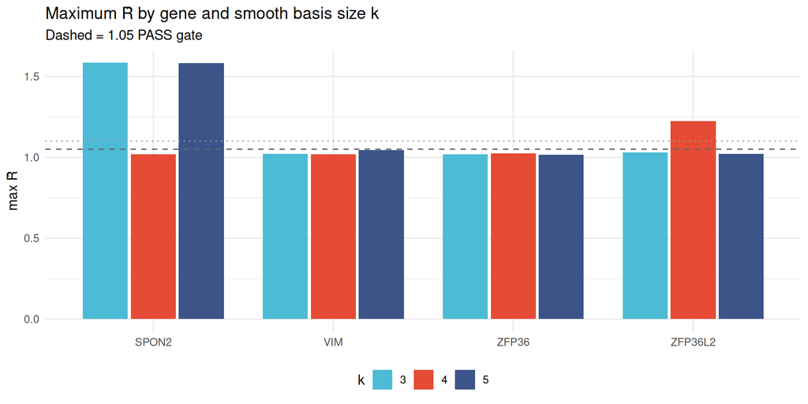

```r
ggplot(diag_view, aes(x = gene, y = max_rhat, fill = k)) +
  geom_col(position = position_dodge(width = 0.8), width = 0.75) +
  geom_hline(yintercept = 1.05, linetype = 2, colour = "grey40") +
  geom_hline(yintercept = 1.1, linetype = 3, colour = "grey60") +
  scale_fill_manual(values = k_colours) +
  labs(
    title = "Maximum R̂ by gene and smooth basis size k",
    subtitle = "Dashed = 1.05 PASS gate",
    x = NULL, y = "max R̂", fill = "k"
  ) +
  theme(legend.position = "bottom")
```

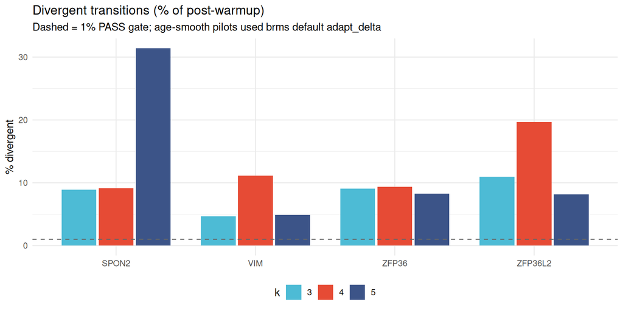

```r
ggplot(diag_view, aes(x = gene, y = pct_divergent, fill = k)) +
  geom_col(position = position_dodge(width = 0.8), width = 0.75) +
  geom_hline(yintercept = 1, linetype = 2, colour = "grey40") +
  scale_fill_manual(values = k_colours) +
  labs(
    title = "Divergent transitions (% of post-warmup)",
    subtitle = "Dashed = 1% PASS gate; age-smooth pilots used brms default adapt_delta",
    x = NULL, y = "% divergent", fill = "k"
  ) +
  theme(legend.position = "bottom")
```

```r
n_pass <- sum(diag_view$gate == "PASS")
n_warn <- sum(diag_view$gate == "WARN")
n_fail <- sum(diag_view$gate == "FAIL")
worst <- diag_view |> arrange(desc(max_rhat)) |> slice(1)
cat(glue(
  "Across {nrow(diag_view)} gene × k cells: **{n_pass} PASS**, **{n_warn} WARN**, ",
  "**{n_fail} FAIL**. Worst max R̂ = **{round(worst$max_rhat, 3)}** for ",
  "**{worst$gene} / k={worst$k}** ({round(worst$pct_divergent, 1)}% divergent)."
))
```

Across 12 gene × k cells: **0 PASS**, **10 WARN**, **2 FAIL**. Worst max R̂ = **1.584** for **SPON2 / k=3** (8.9% divergent).

# 2. Age-smooth curves (blood & liver)

The report curve is the population-level (`re_formula = NA`) linear predictor, with `offset = 0`, versus `age_days_scaled`. To make its absolute level reproducible, ethnicity and assay are fixed to their most frequent values in the fit instead of being inherited from the first matching training row. Each curve is restricted to its tissue–sex group’s observed 5th–95th percentile age range to avoid extrapolating the sparse liver strata. Curves show the posterior mean and pointwise 95% interval for **blood** and **liver**, faceted by sex; colours denote k.

```r
curves_path <- params$curves_rds
need_curves <- isTRUE(params$refresh) || !file.exists(curves_path)

if (need_curves) {
  message("Building blood/liver age curves ...")
  inv_ok <- inv |> filter(available)
  curve_rows <- vector("list", nrow(inv_ok))
  for (i in seq_len(nrow(inv_ok))) {
    row <- inv_ok[i, ]
    message(sprintf("[%d/%d] curves %s k=%d", i, nrow(inv_ok), row$gene, row$k))
    fit <- readRDS(row$rds_path)
    curve_rows[[i]] <- age_smooth_curve_draws(
      fit,
      tissues = c("blood", "liver"),
      n_age = 40L,
      ndraws = params$n_curve_draws,
      re_formula = NA
    ) |>
      mutate(gene = row$gene, k = factor(row$k, levels = ks))
  }
  curves <- bind_rows(curve_rows)
  dir.create(dirname(curves_path), recursive = TRUE, showWarnings = FALSE)
  saveRDS(curves, curves_path, compress = "xz")
} else {
  curves <- readRDS(curves_path)
}
```

```r
curves |>
  distinct(gene, k, reference_profile) |>
  arrange(gene, k)
```

| gene | k | reference_profile |
| --- | --- | --- |
| SPON2 | 3 | ethnicity_groups=European; assay_groups=10x Genomics 3 |
| SPON2 | 4 | ethnicity_groups=European; assay_groups=10x Genomics 3 |
| SPON2 | 5 | ethnicity_groups=European; assay_groups=10x Genomics 3 |
| VIM | 3 | ethnicity_groups=European; assay_groups=10x Genomics 3 |
| VIM | 4 | ethnicity_groups=European; assay_groups=10x Genomics 3 |
| VIM | 5 | ethnicity_groups=European; assay_groups=10x Genomics 3 |
| ZFP36 | 3 | ethnicity_groups=European; assay_groups=10x Genomics 3 |
| ZFP36 | 4 | ethnicity_groups=European; assay_groups=10x Genomics 3 |
| ZFP36 | 5 | ethnicity_groups=European; assay_groups=10x Genomics 3 |
| ZFP36L2 | 3 | ethnicity_groups=European; assay_groups=10x Genomics 3 |

[output cut: 2 more lines]

```r
curves |>
  distinct(tissue_groups, sex, support_lower, support_upper) |>
  mutate(across(c(support_lower, support_upper), ~ round(.x, 3))) |>
  arrange(tissue_groups, sex)
```

| tissue_groups | sex | support_lower | support_upper |
| --- | --- | --- | --- |
| blood | female | -1.298 | 1.597 |
| blood | male | -1.408 | 1.558 |
| liver | female | -1.128 | 1.268 |
| liver | male | -1.248 | 1.098 |

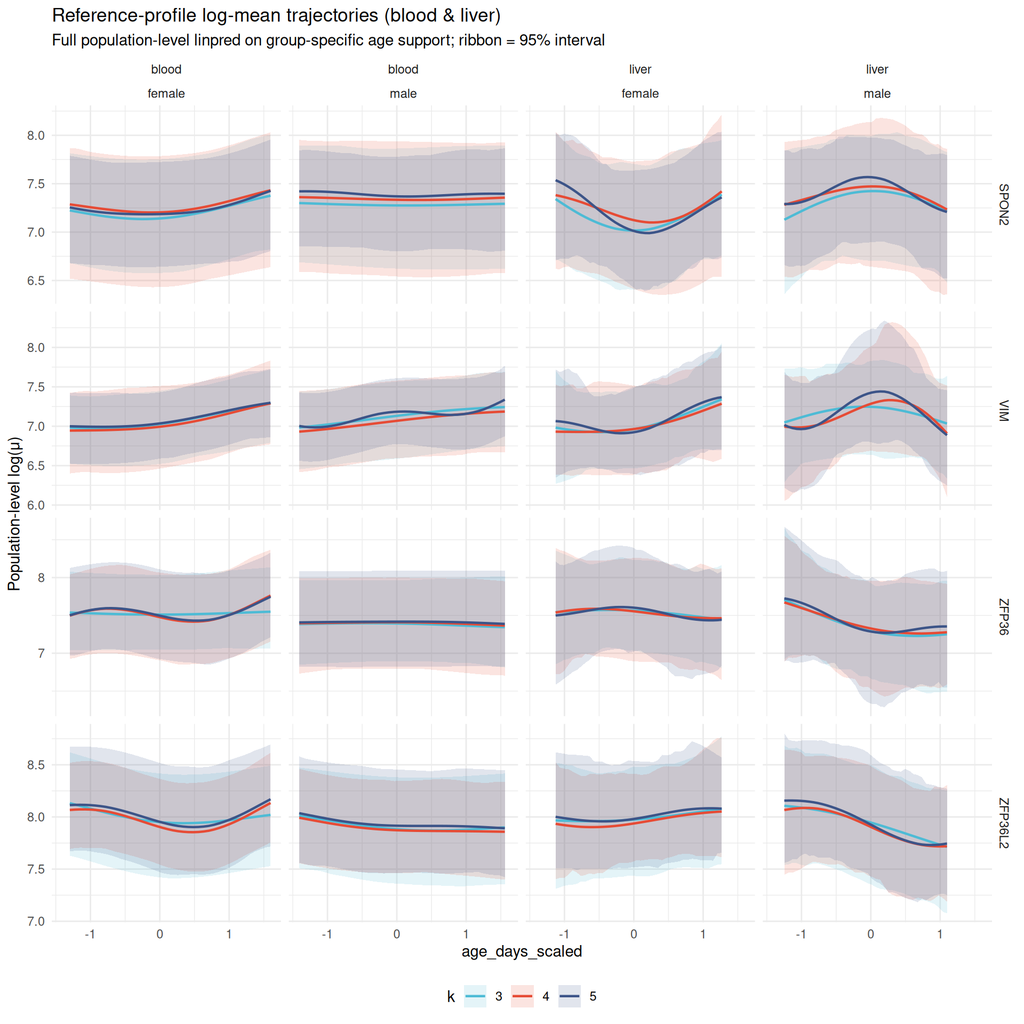

```r
ggplot(curves, aes(x = age_days_scaled, y = estimate, colour = k, fill = k)) +
  geom_ribbon(aes(ymin = lower, ymax = upper), alpha = 0.15, colour = NA) +
  geom_line(linewidth = 0.8) +
  facet_grid(gene ~ tissue_groups + sex, scales = "free_y") +
  scale_colour_manual(values = k_colours) +
  scale_fill_manual(values = k_colours) +
  labs(
    title = "Reference-profile log-mean trajectories (blood & liver)",
    subtitle = "Full population-level linpred on group-specific age support; ribbon = 95% interval",
    x = "age_days_scaled",
    y = "Population-level log(μ)",
    colour = "k", fill = "k"
  ) +
  theme(legend.position = "bottom")
```

## What `conditional_smooths()` computes

The two curve APIs answer different questions. The report helper evaluates the **full** count-component linear predictor, whereas [`brms::conditional_smooths()`](https://paulbuerkner.com/brms/reference/conditional_smooths.brmsfit.html) uses `posterior_smooths()` internally to isolate the contribution from the selected smooth term.

| Feature | Report helper: `age_smooth_curve_draws()` | `brms::conditional_smooths()` |
| --- | --- | --- |
| Quantity | Full population-level `log(μ)` linear predictor | Only `s(age_days_scaled, by = tissue_sex, ...)` |
| Included terms | Intercept, sex, reference ethnicity/assay, smooth | Smooth term only |
| Group-level terms | Excluded by `re_formula = NA` | Not part of the isolated smooth |
| Offset | Set to 0 | Not part of the isolated smooth |
| Point estimate | Posterior mean | Posterior median |
| Interval | Pointwise 2.5% and 97.5% quantiles | Pointwise 2.5% and 97.5% quantiles |
| Default age grid | Group-specific 5th–95th percentiles, 40 points | Full observed range, 100 points |
| Grid used below | Group-specific 5th–95th percentiles, 40 points | Matched to the report helper |

Thus, the raw vertical positions should **not** agree: the brms curve is a smooth-term contribution, not an absolute expected log mean. Their age-dependent shapes should agree after removing an age-invariant vertical shift, up to mean-versus-median summarisation and posterior Monte Carlo error.

```r
conditional_path <- params$conditional_smooths_rds
need_conditional <- isTRUE(params$refresh) || !file.exists(conditional_path)

if (need_conditional) {
  message("Building brms conditional_smooths curves ...")
  inv_ok <- inv |> filter(available)
  conditional_rows <- vector("list", nrow(inv_ok))
  for (i in seq_len(nrow(inv_ok))) {
    row <- inv_ok[i, ]
    message(sprintf(
      "[%d/%d] conditional_smooths %s k=%d",
      i, nrow(inv_ok), row$gene, row$k
    ))
    fit <- readRDS(row$rds_path)
    conditional_rows[[i]] <- age_smooth_conditional_smooths(
      fit,
      tissues = c("blood", "liver"),
      n_age = 40L,
      ndraws = params$n_curve_draws
    ) |>
      mutate(gene = row$gene, k = factor(row$k, levels = ks))
  }
  conditional_curves <- bind_rows(conditional_rows)
  dir.create(dirname(conditional_path), recursive = TRUE, showWarnings = FALSE)
  saveRDS(conditional_curves, conditional_path, compress = "xz")
} else {
  conditional_curves <- readRDS(conditional_path)
}
```

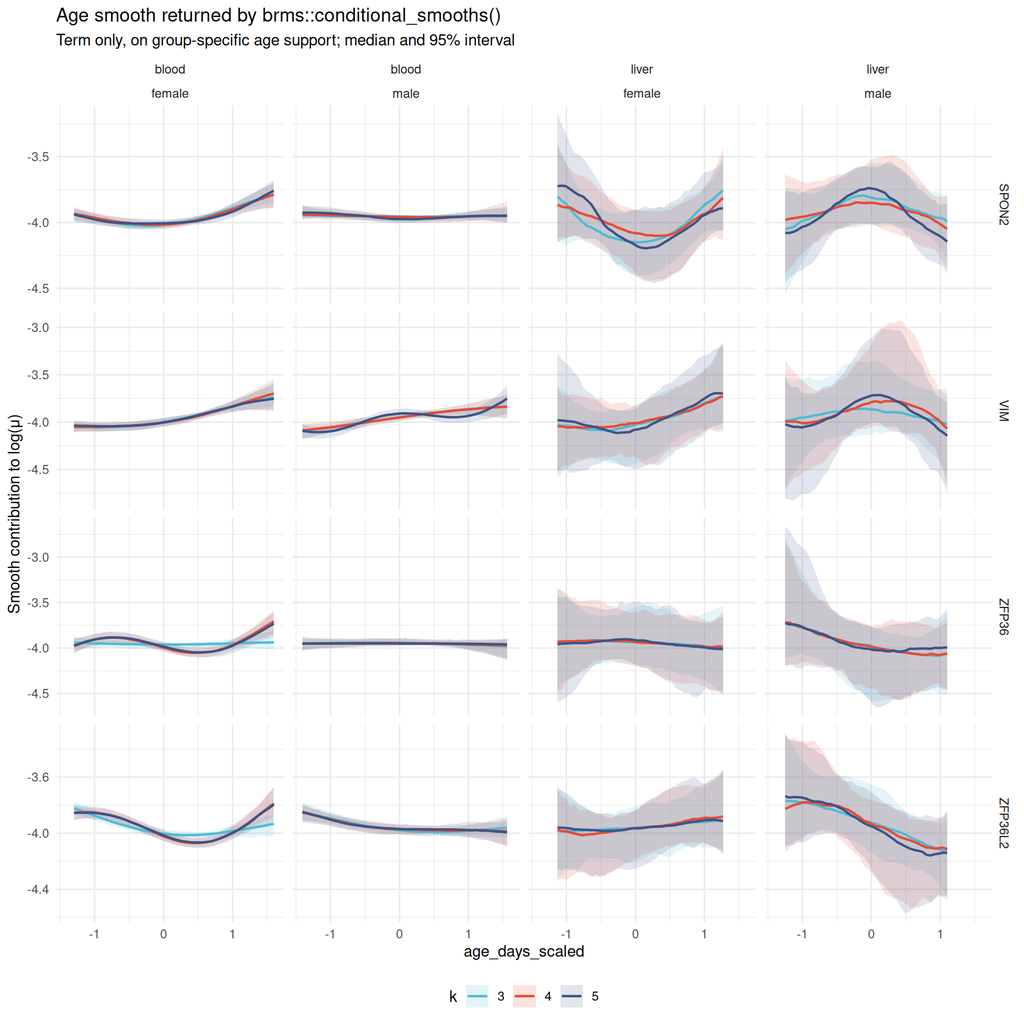

```r
ggplot(
  conditional_curves,
  aes(x = age_days_scaled, y = estimate, colour = k, fill = k)
) +
  geom_ribbon(aes(ymin = lower, ymax = upper), alpha = 0.15, colour = NA) +
  geom_line(linewidth = 0.8) +
  facet_grid(gene ~ tissue_groups + sex, scales = "free_y") +
  scale_colour_manual(values = k_colours) +
  scale_fill_manual(values = k_colours) +
  labs(
    title = "Age smooth returned by brms::conditional_smooths()",
    subtitle = "Term only, on group-specific age support; median and 95% interval",
    x = "age_days_scaled",
    y = "Smooth contribution to log(μ)",
    colour = "k", fill = "k"
  ) +
  theme(legend.position = "bottom")
```

## Shape comparison on a common zero

For visual comparison, each method’s point-estimate curve is shifted to zero at the grid point nearest `age_days_scaled = 0`. This removes the non-age terms from the full linear predictor. It is a comparison of displayed point estimates, not a new posterior estimand.

```r
curve_comparison <- bind_rows(
  curves |>
    transmute(
      gene, k, tissue_groups, sex, age_days_scaled, estimate,
      method = "Full linpred (mean)"
    ),
  conditional_curves |>
    transmute(
      gene, k, tissue_groups, sex, age_days_scaled, estimate,
      method = "conditional_smooths (median)"
    )
) |>
  group_by(gene, k, tissue_groups, sex, method) |>
  arrange(age_days_scaled, .by_group = TRUE) |>
  mutate(
    anchor = estimate[which.min(abs(age_days_scaled))],
    centred_estimate = estimate - anchor
  ) |>
  ungroup()

shape_difference <- curve_comparison |>
  select(
    gene, k, tissue_groups, sex, age_days_scaled, method, centred_estimate
  ) |>
  pivot_wider(names_from = method, values_from = centred_estimate) |>
  mutate(
    difference = `Full linpred (mean)` - `conditional_smooths (median)`
  )

shape_difference |>
  group_by(gene, k, tissue_groups, sex) |>
  summarise(
    max_abs_difference = max(abs(difference)),
    rmse = sqrt(mean(difference^2)),
    .groups = "drop"
  ) |>
  mutate(across(c(max_abs_difference, rmse), ~ round(.x, 4))) |>
  arrange(desc(max_abs_difference))
```

| gene | k | tissue_groups | sex | max_abs_difference | rmse |
| --- | --- | --- | --- | --- | --- |
| ZFP36 | 3 | liver | male | 0.1532 | 0.0648 |
| ZFP36 | 5 | liver | male | 0.1514 | 0.0715 |
| VIM | 5 | liver | male | 0.1318 | 0.0748 |
| VIM | 4 | liver | male | 0.0964 | 0.0548 |
| ZFP36 | 5 | liver | female | 0.0857 | 0.0469 |
| SPON2 | 5 | liver | female | 0.0793 | 0.0263 |
| VIM | 3 | liver | male | 0.0763 | 0.0312 |
| ZFP36 | 4 | liver | male | 0.0763 | 0.0366 |
| VIM | 3 | liver | female | 0.0753 | 0.0344 |
| VIM | 5 | liver | female | 0.0667 | 0.0344 |

[output cut: 38 more lines]

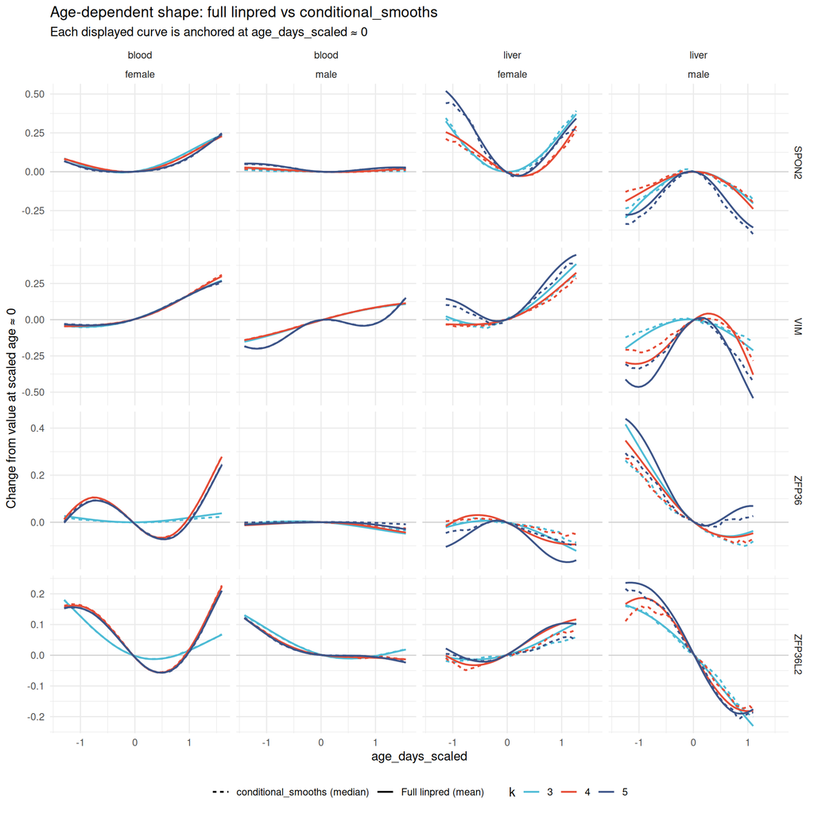

```r
ggplot(
  curve_comparison,
  aes(
    x = age_days_scaled,
    y = centred_estimate,
    colour = k,
    linetype = method
  )
) +
  geom_hline(yintercept = 0, colour = "grey80", linewidth = 0.35) +
  geom_line(linewidth = 0.75) +
  facet_grid(gene ~ tissue_groups + sex, scales = "free_y") +
  scale_colour_manual(values = k_colours) +
  scale_linetype_manual(values = c(
    `Full linpred (mean)` = "solid",
    `conditional_smooths (median)` = "22"
  )) +
  labs(
    title = "Age-dependent shape: full linpred vs conditional_smooths",
    subtitle = "Each displayed curve is anchored at age_days_scaled ≈ 0",
    x = "age_days_scaled",
    y = "Change from value at scaled age ≈ 0",
    colour = "k",
    linetype = NULL
  ) +
  theme(legend.position = "bottom")
```

```r
shape_audit <- shape_difference |>
  group_by(gene, k, tissue_groups, sex) |>
  summarise(
    max_abs_difference = max(abs(difference)),
    .groups = "drop"
  )
largest_shape_difference <- shape_audit |>
  arrange(desc(max_abs_difference)) |>
  slice(1)

cat(glue(
  "After anchoring, the median group-wise maximum absolute difference is ",
  "**{round(median(shape_audit$max_abs_difference), 3)} log units**. ",
  "The largest is **{round(largest_shape_difference$max_abs_difference, 3)}** ",
  "for **{largest_shape_difference$gene}, k={largest_shape_difference$k}, ",
  "{largest_shape_difference$tissue_groups}, ",
  "{largest_shape_difference$sex}**. Residual discrepancies are expected because ",
  "the full curve is summarised by the posterior mean whereas ",
  "`conditional_smooths()` uses the posterior median; sparse liver strata also ",
  "have wider, more skewed posteriors. For absolute `log(μ)`, retain the full ",
  "linear predictor. For the isolated age-shape diagnostic, use ",
  "`conditional_smooths()`."
))
```

After anchoring, the median group-wise maximum absolute difference is **0.025 log units**. The largest is **0.153** for **ZFP36, k=3, liver, male**. Residual discrepancies are expected because the full curve is summarised by the posterior mean whereas `conditional_smooths()` uses the posterior median; sparse liver strata also have wider, more skewed posteriors. For absolute `log(μ)`, retain the full linear predictor. For the isolated age-shape diagnostic, use `conditional_smooths()`.

# 3. brms predict / linpred compatibility

Smoke-test on one fit per gene (prefer k=4 when available) to confirm the prediction API used for comprehensive μ works on smooth objects.

```r
compat_path <- params$compat_csv
need_compat <- isTRUE(params$refresh) || !file.exists(compat_path)

if (need_compat) {
  compat_rows <- list()
  for (g in genes) {
    prefer <- inv |> filter(gene == g, k == 4L, available)
    if (!nrow(prefer)) {
      prefer <- inv |> filter(gene == g, available) |> slice(1)
    }
    if (!nrow(prefer)) next
    message("Compat checks: ", prefer$gene, " k=", prefer$k)
    fit <- readRDS(prefer$rds_path[[1]])
    compat_rows[[g]] <- age_smooth_predict_compat(fit, ndraws = 50L) |>
      mutate(gene = prefer$gene, k = prefer$k)
  }
  compat <- bind_rows(compat_rows)
  write_csv(compat, compat_path)
} else {
  compat <- read_csv(compat_path, show_col_types = FALSE)
}

compat |>
  mutate(
    elapsed_sec = round(elapsed_sec, 2),
    ok = if_else(ok, "YES", "NO")
  ) |>
  arrange(gene, check)
```

| check | ok | detail | elapsed_sec | gene | k |
| --- | --- | --- | --- | --- | --- |
| comprehensive liver linpred | YES | dim=50x1 | 0.53 | SPON2 | 4 |
| posterior_epred | YES | dim=50x5 | 0.44 | SPON2 | 4 |
| posterior_linpred (re_formula=NA) | YES | dim=50x5 | 0.41 | SPON2 | 4 |
| posterior_linpred (re_formula=NULL) | YES | dim=50x5 | 0.73 | SPON2 | 4 |
| posterior_predict | YES | dim=50x5 | 0.42 | SPON2 | 4 |
| comprehensive liver linpred | YES | dim=50x1 | 0.81 | VIM | 4 |
| posterior_epred | YES | dim=50x5 | 0.42 | VIM | 4 |
| posterior_linpred (re_formula=NA) | YES | dim=50x5 | 0.48 | VIM | 4 |
| posterior_linpred (re_formula=NULL) | YES | dim=50x5 | 0.53 | VIM | 4 |
| posterior_predict | YES | dim=50x5 | 0.43 | VIM | 4 |

[output cut: 10 more lines]

```r
n_ok <- sum(compat$ok %in% c(TRUE, "YES"))
n_tot <- nrow(compat)
if (n_ok == n_tot) {
  cat(glue(
    "All **{n_tot}** prediction checks passed, including `posterior_linpred` ",
    "and the comprehensive liver baseline helper — smooth fits are usable for μ."
  ))
} else {
  bad <- compat |> filter(!ok %in% c(TRUE, "YES"))
  cat(glue(
    "**{n_ok}/{n_tot}** checks passed. Failures: ",
    "{paste(bad$gene, bad$check, sep = '/', collapse = '; ')}."
  ))
}
```

All **20** prediction checks passed, including `posterior_linpred` and the comprehensive liver baseline helper — smooth fits are usable for μ.

# 4. Baseline μ / SD vs strong RE (simple shape)

Comprehensive healthy **liver** baseline:

- **Age-smooth** — average `posterior_linpred` over sex × ethnicity × assay × age quantile grid (`build_comprehensive_grid_age_smooth`).
- **Strong RE** — existing comprehensive grid (`age_decade` margins) from the formula-comparison helpers.

Densities use `n_baseline_draws` posterior draws of the scalar baseline `log(μ)`.

```r
draws_path <- params$baseline_draws_rds
need_draws <- isTRUE(params$refresh) || !file.exists(draws_path)

if (need_draws) {
  message("Collecting baseline draws (smooth + RE) ...")
  out <- list()

  inv_ok <- inv |> filter(available)
  for (i in seq_len(nrow(inv_ok))) {
    row <- inv_ok[i, ]
    message(sprintf("[smooth %d/%d] %s k=%d", i, nrow(inv_ok), row$gene, row$k))
    fit <- readRDS(row$rds_path)
    d <- linpred_baseline_draws_age_smooth(
      fit, ndraws = params$n_baseline_draws
    ) |>
      mutate(
        gene = row$gene,
        model = paste0("Age-smooth k=", row$k),
        k = row$k,
        family = "age_smooth"
      )
    out[[length(out) + 1L]] <- d
  }

  for (g in genes) {
    re_path <- file.path(params$strong_out_dir, paste0("fit_re_", g, ".rds"))
    if (!file.exists(re_path)) next
    message("RE baseline: ", g)
    fit_re <- readRDS(re_path)
    d <- linpred_baseline_draws(fit_re, ndraws = params$n_baseline_draws) |>
      mutate(
        gene = g,
        model = "RE HMC (simple)",
        k = NA_integer_,
        family = "re"
      )
    out[[length(out) + 1L]] <- d
  }

  baseline_draws <- bind_rows(out)
  dir.create(dirname(draws_path), recursive = TRUE, showWarnings = FALSE)
  saveRDS(baseline_draws, draws_path, compress = "xz")
} else {
  baseline_draws <- readRDS(draws_path)
}

baseline_draws <- baseline_draws |>
  mutate(
    model = factor(model, levels = names(model_colours))
  )

baseline_summary <- baseline_draws |>
  group_by(gene, model, family, k) |>
  summarise(
    n_draws = n(),
    mean_log_mu = mean(baseline_log_mu),
    sd_log_mu = sd(baseline_log_mu),
    .groups = "drop"
  )
```

## Mean / SD table

```r
baseline_summary |>
  mutate(
    mean_log_mu = round(mean_log_mu, 3),
    sd_log_mu = round(sd_log_mu, 3)
  ) |>
  arrange(gene, family, k)
```

| gene | model | family | k | n_draws | mean_log_mu | sd_log_mu |
| --- | --- | --- | --- | --- | --- | --- |
| SPON2 | Age-smooth k=3 | age_smooth | 3 | 400 | 6.971 | 0.903 |
| SPON2 | Age-smooth k=4 | age_smooth | 4 | 400 | 6.874 | 0.802 |
| SPON2 | Age-smooth k=5 | age_smooth | 5 | 400 | 6.957 | 0.843 |
| SPON2 | RE HMC (simple) | re | NA | 400 | 7.017 | 1.074 |
| VIM | Age-smooth k=3 | age_smooth | 3 | 400 | 5.730 | 1.318 |
| VIM | Age-smooth k=4 | age_smooth | 4 | 400 | 5.780 | 1.391 |
| VIM | Age-smooth k=5 | age_smooth | 5 | 400 | 5.839 | 1.399 |
| VIM | RE HMC (simple) | re | NA | 400 | 6.181 | 1.539 |
| ZFP36 | Age-smooth k=3 | age_smooth | 3 | 400 | 6.338 | 1.558 |
| ZFP36 | Age-smooth k=4 | age_smooth | 4 | 400 | 6.528 | 1.379 |

[output cut: 6 more lines]

## Smooth vs RE deltas

```r
deltas <- baseline_summary |>
  select(gene, model, mean_log_mu, sd_log_mu) |>
  pivot_wider(
    names_from = model,
    values_from = c(mean_log_mu, sd_log_mu)
  )

# Build delta columns relative to RE when present
re_mean_col <- "mean_log_mu_RE HMC (simple)"
re_sd_col <- "sd_log_mu_RE HMC (simple)"
smooth_mean_cols <- grep("^mean_log_mu_Age-smooth", names(deltas), value = TRUE)
smooth_sd_cols <- grep("^sd_log_mu_Age-smooth", names(deltas), value = TRUE)

if (re_mean_col %in% names(deltas)) {
  for (col in smooth_mean_cols) {
    deltas[[paste0("delta_", col)]] <- deltas[[col]] - deltas[[re_mean_col]]
  }
  for (col in smooth_sd_cols) {
    deltas[[paste0("ratio_", col)]] <- deltas[[col]] / deltas[[re_sd_col]]
  }
}

deltas |>
  mutate(across(where(is.numeric), ~ round(.x, 3))) |>
  arrange(gene)
```

| gene | mean_log_mu_RE HMC (simple) | mean_log_mu_Age-smooth k=3 | mean_log_mu_Age-smooth k=4 | mean_log_mu_Age-smooth k=5 | sd_log_mu_RE HMC (simple) | sd_log_mu_Age-smooth k=3 | sd_log_mu_Age-smooth k=4 | sd_log_mu_Age-smooth k=5 | delta_mean_log_mu_Age-smooth k=3 | delta_mean_log_mu_Age-smooth k=4 | delta_mean_log_mu_Age-smooth k=5 | ratio_sd_log_mu_Age-smooth k=3 | ratio_sd_log_mu_Age-smooth k=4 | ratio_sd_log_mu_Age-smooth k=5 |
| --- | --- | --- | --- | --- | --- | --- | --- | --- | --- | --- | --- | --- | --- | --- |
| SPON2 | 7.017 | 6.971 | 6.874 | 6.957 | 1.074 | 0.903 | 0.802 | 0.843 | -0.045 | -0.143 | -0.060 | 0.841 | 0.746 | 0.785 |
| VIM | 6.181 | 5.730 | 5.780 | 5.839 | 1.539 | 1.318 | 1.391 | 1.399 | -0.450 | -0.400 | -0.342 | 0.856 | 0.903 | 0.909 |
| ZFP36 | 6.921 | 6.338 | 6.528 | 6.541 | 1.505 | 1.558 | 1.379 | 1.508 | -0.583 | -0.393 | -0.380 | 1.035 | 0.916 | 1.002 |
| ZFP36L2 | 6.946 | 6.614 | 6.822 | 6.714 | 1.295 | 1.117 | 1.228 | 1.194 | -0.332 | -0.124 | -0.231 | 0.863 | 0.948 | 0.922 |

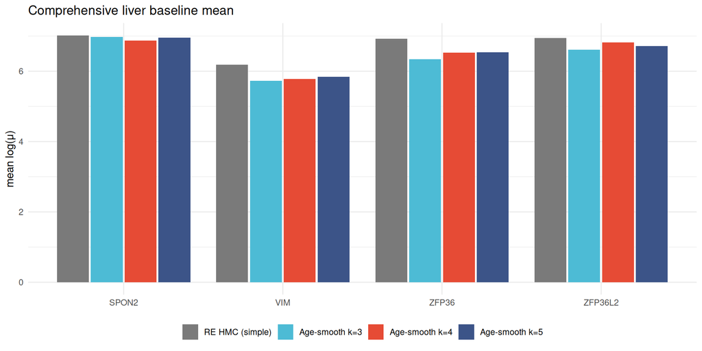

```r
sum_plot <- baseline_summary |>
  mutate(k_label = if_else(is.na(k), "RE", as.character(k)))

p1 <- ggplot(sum_plot, aes(x = gene, y = mean_log_mu, fill = model)) +
  geom_col(position = position_dodge(width = 0.85), width = 0.8) +
  scale_fill_manual(values = model_colours, drop = FALSE) +
  labs(title = "Comprehensive liver baseline mean", y = "mean log(μ)", x = NULL, fill = NULL) +
  theme(legend.position = "bottom")

p2 <- ggplot(sum_plot, aes(x = gene, y = sd_log_mu, fill = model)) +
  geom_col(position = position_dodge(width = 0.85), width = 0.8) +
  scale_fill_manual(values = model_colours, drop = FALSE) +
  labs(title = "Comprehensive liver baseline SD", y = "SD log(μ)", x = NULL, fill = NULL) +
  theme(legend.position = "bottom")

p1
```

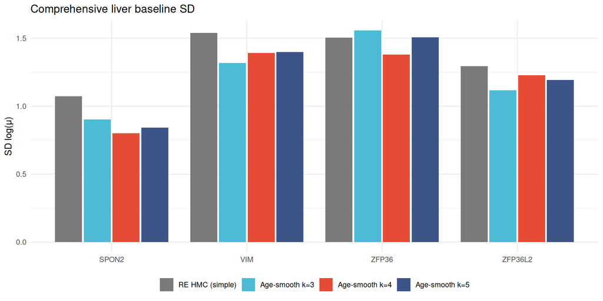

```r
p2
```

## Overlapping baseline densities

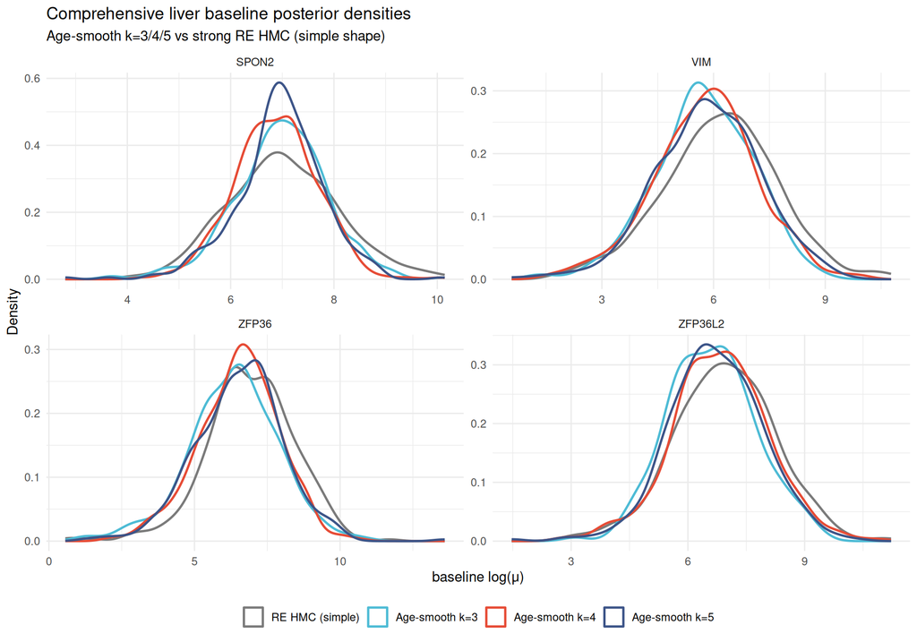

```r
ggplot(baseline_draws, aes(x = baseline_log_mu, colour = model)) +
  geom_density(linewidth = 0.85) +
  facet_wrap(~ gene, scales = "free") +
  scale_colour_manual(values = model_colours, drop = FALSE) +
  labs(
    title = "Comprehensive liver baseline posterior densities",
    subtitle = "Age-smooth k=3/4/5 vs strong RE HMC (simple shape)",
    x = "baseline log(μ)", y = "Density", colour = NULL
  ) +
  theme(legend.position = "bottom")
```

```r
best_k <- diag_view |>
  group_by(k) |>
  summarise(
    median_rhat = median(max_rhat, na.rm = TRUE),
    median_div = median(pct_divergent, na.rm = TRUE),
    n_pass = sum(gate == "PASS"),
    .groups = "drop"
  ) |>
  arrange(desc(n_pass), median_rhat)

re_vs <- baseline_summary |>
  filter(family == "age_smooth") |>
  left_join(
    baseline_summary |>
      filter(family == "re") |>
      select(gene, re_mean = mean_log_mu, re_sd = sd_log_mu),
    by = "gene"
  ) |>
  mutate(
    abs_mean_shift = abs(mean_log_mu - re_mean),
    sd_ratio = sd_log_mu / re_sd
  )

cat(glue(
  "Best k by gate/R̂: **k={best_k$k[1]}** ",
  "({best_k$n_pass[1]} PASS; median R̂={round(best_k$median_rhat[1], 3)}; ",
  "median %div={round(best_k$median_div[1], 1)}). ",
  "Median |smooth − RE| baseline mean shift: ",
  "**{round(median(re_vs$abs_mean_shift, na.rm = TRUE), 3)}**; ",
  "median SD ratio (smooth/RE): ",
  "**{round(median(re_vs$sd_ratio, na.rm = TRUE), 3)}**. ",
  "Note: smooth fits use healthy-only data; RE used the full disease mix."
))
```

Best k by gate/R̂: **k=4** (0 PASS; median R̂=1.022; median %div=10.2). Median |smooth − RE| baseline mean shift: **0.337**; median SD ratio (smooth/RE): **0.906**. Note: smooth fits use healthy-only data; RE used the full disease mix.

# 5. Fitting-time benchmark (`formula_bench`)

Wall-clock HMC times from the `targets` pipeline under `targets/formula_bench/`. All cells use the same healthy-only frame (n = 2905), MCMC length 400 warmup / 900 iter, and `control = NULL`. The grid crosses four genes × five formulas × three resource settings:

| setting_id | Chains | Slurm CPUs | Threads / chain |
| --- | --- | --- | --- |
| `c2_cpu8` | 2 | 8 | 4 |
| `c4_cpu8` | 4 | 8 | 2 |
| `c4_cpu16` | 4 | 16 | 4 |

Formulas: age-smooth k ∈ {3,4,5} (`AGE-k*`) plus healthy-adapted RE (`RE-simple`, `RE-split`). Times are exclusive of data prep; they measure `brms::brm()` wall clock on the assigned Slurm controller.

```r
timing_raw <- read_csv(params$timing_summary_csv, show_col_types = FALSE)

timing <- timing_raw |>
  mutate(
    formula_id = factor(
      formula_id,
      levels = c("AGE-k3", "AGE-k4", "AGE-k5", "RE-simple", "RE-split")
    ),
    setting_id = factor(
      setting_id,
      levels = c("c2_cpu8", "c4_cpu8", "c4_cpu16")
    ),
    setting_label = factor(
      case_when(
        setting_id == "c2_cpu8" ~ "2×8 (4 thr)",
        setting_id == "c4_cpu8" ~ "4×8 (2 thr)",
        setting_id == "c4_cpu16" ~ "4×16 (4 thr)",
        TRUE ~ as.character(setting_label)
      ),
      levels = names(setting_colours)
    ),
    family_group = if_else(family == "age_smooth", "Age-smooth", "RE"),
    elapsed_min = elapsed_sec / 60,
    gene = factor(gene, levels = genes)
  )

stopifnot(all(timing$fit_ok))
```

```r
cat(glue(
  "**{nrow(timing)}/{nrow(timing)}** benchmark fits succeeded ",
  "({n_distinct(timing$gene)} genes × {n_distinct(timing$formula_id)} formulas × ",
  "{n_distinct(timing$setting_id)} settings). ",
  "Source: `{params$timing_summary_csv}`."
))
```

**60/60** benchmark fits succeeded (4 genes × 5 formulas × 3 settings). Source: `/home/a1237163/lab/chen/posteriorHCA/dev/Jie_HCC/data/processed/formula_bench/timing_summary.csv`.

## Timing table (minutes)

```r
timing |>
  transmute(
    gene,
    formula_id,
    setting = setting_label,
    threads = threads_per_chain,
    elapsed_min = round(elapsed_min, 1),
    max_rhat = round(max_rhat, 3)
  ) |>
  arrange(gene, formula_id, setting)
```

| gene | formula_id | setting | threads | elapsed_min | max_rhat |
| --- | --- | --- | --- | --- | --- |
| SPON2 | AGE-k3 | 2×8 (4 thr) | 4 | 14.6 | 1.060 |
| SPON2 | AGE-k3 | 4×8 (2 thr) | 2 | 50.8 | 1.176 |
| SPON2 | AGE-k3 | 4×16 (4 thr) | 4 | 14.7 | 1.021 |
| SPON2 | AGE-k4 | 2×8 (4 thr) | 4 | 13.8 | 1.030 |
| SPON2 | AGE-k4 | 4×8 (2 thr) | 2 | 52.6 | 1.024 |
| SPON2 | AGE-k4 | 4×16 (4 thr) | 4 | 13.8 | 1.037 |
| SPON2 | AGE-k5 | 2×8 (4 thr) | 4 | 13.2 | 1.026 |
| SPON2 | AGE-k5 | 4×8 (2 thr) | 2 | 25.5 | 1.022 |
| SPON2 | AGE-k5 | 4×16 (4 thr) | 4 | 14.1 | 1.025 |
| SPON2 | RE-simple | 2×8 (4 thr) | 4 | 13.1 | 2.250 |

[output cut: 50 more lines]

## Elapsed time by formula and resource setting

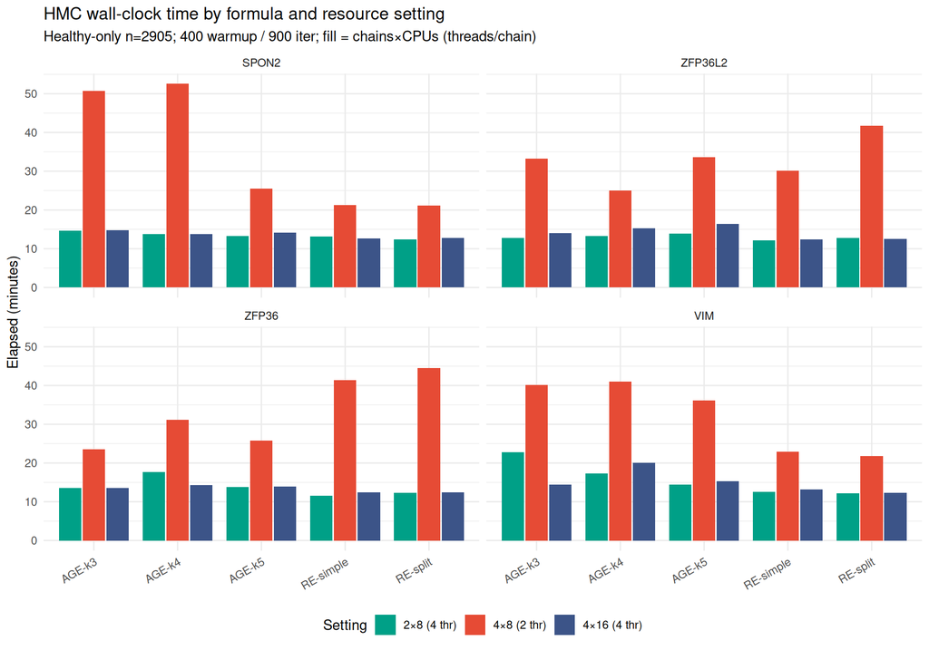

```r
ggplot(timing, aes(x = formula_id, y = elapsed_min, fill = setting_label)) +
  geom_col(position = position_dodge(width = 0.85), width = 0.8) +
  facet_wrap(~ gene, nrow = 2) +
  scale_fill_manual(values = setting_colours) +
  labs(
    title = "HMC wall-clock time by formula and resource setting",
    subtitle = "Healthy-only n=2905; 400 warmup / 900 iter; fill = chains×CPUs (threads/chain)",
    x = NULL, y = "Elapsed (minutes)", fill = "Setting"
  ) +
  theme(
    legend.position = "bottom",
    axis.text.x = element_text(angle = 30, hjust = 1)
  )
```

## Age-smooth k vs RE under each setting

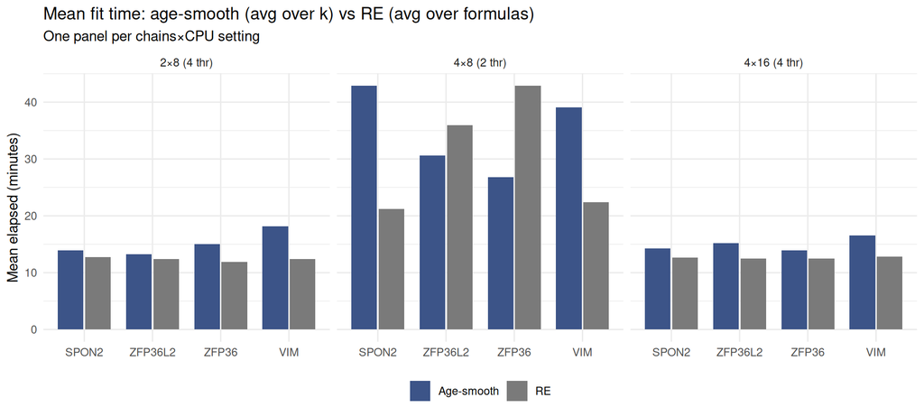

```r
timing_family <- timing |>
  group_by(gene, setting_label, family_group) |>
  summarise(
    elapsed_min = mean(elapsed_min),
    .groups = "drop"
  )

ggplot(
  timing_family,
  aes(x = gene, y = elapsed_min, fill = family_group)
) +
  geom_col(position = position_dodge(width = 0.8), width = 0.75) +
  facet_wrap(~ setting_label, nrow = 1) +
  scale_fill_manual(
    values = c(`Age-smooth` = "#3C5488", `RE` = "#7A7A7A")
  ) +
  labs(
    title = "Mean fit time: age-smooth (avg over k) vs RE (avg over formulas)",
    subtitle = "One panel per chains×CPU setting",
    x = NULL, y = "Mean elapsed (minutes)", fill = NULL
  ) +
  theme(legend.position = "bottom")
```

## Effect of k on age-smooth fit time

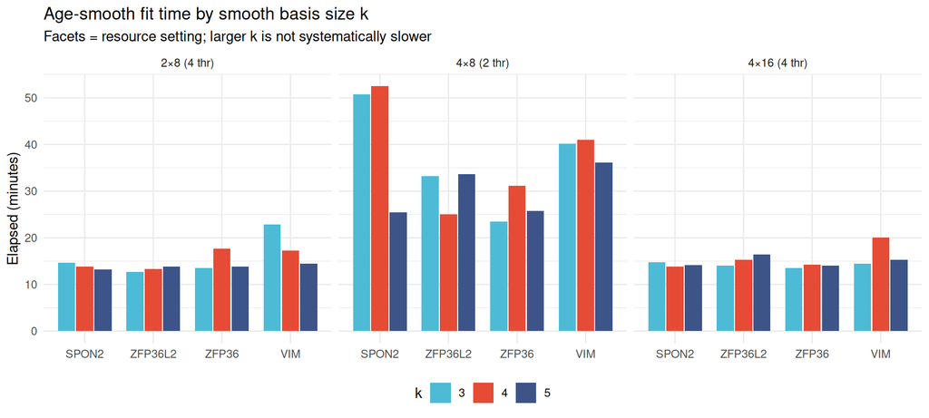

```r
timing_age <- timing |>
  filter(family == "age_smooth") |>
  mutate(k = factor(k, levels = ks))

ggplot(timing_age, aes(x = gene, y = elapsed_min, fill = k)) +
  geom_col(position = position_dodge(width = 0.8), width = 0.75) +
  facet_wrap(~ setting_label, nrow = 1) +
  scale_fill_manual(values = k_colours) +
  labs(
    title = "Age-smooth fit time by smooth basis size k",
    subtitle = "Facets = resource setting; larger k is not systematically slower",
    x = NULL, y = "Elapsed (minutes)", fill = "k"
  ) +
  theme(legend.position = "bottom")
```

## Resource-setting speedup (relative to 4×8)

The pilot default is 4 chains on 8 CPUs (2 within-chain threads). Speedup is elapsed(4×8) / elapsed(setting) for the same gene × formula.

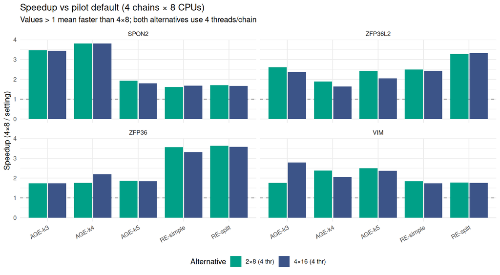

```r
timing_speedup <- timing |>
  select(gene, formula_id, setting_label, elapsed_sec) |>
  pivot_wider(names_from = setting_label, values_from = elapsed_sec) |>
  mutate(
    speedup_2x8 = `4×8 (2 thr)` / `2×8 (4 thr)`,
    speedup_4x16 = `4×8 (2 thr)` / `4×16 (4 thr)`
  ) |>
  select(gene, formula_id, speedup_2x8, speedup_4x16) |>
  pivot_longer(
    cols = starts_with("speedup_"),
    names_to = "alt_setting",
    values_to = "speedup"
  ) |>
  mutate(
    alt_setting = factor(
      recode(
        alt_setting,
        speedup_2x8 = "2×8 (4 thr)",
        speedup_4x16 = "4×16 (4 thr)"
      ),
      levels = c("2×8 (4 thr)", "4×16 (4 thr)")
    )
  )

ggplot(
  timing_speedup,
  aes(x = formula_id, y = speedup, fill = alt_setting)
) +
  geom_hline(yintercept = 1, linetype = 2, colour = "grey50") +
  geom_col(position = position_dodge(width = 0.85), width = 0.8) +
  facet_wrap(~ gene, nrow = 2) +
  scale_fill_manual(
    values = c(`2×8 (4 thr)` = "#00A087", `4×16 (4 thr)` = "#3C5488")
  ) +
  labs(
    title = "Speedup vs pilot default (4 chains × 8 CPUs)",
    subtitle = "Values > 1 mean faster than 4×8; both alternatives use 4 threads/chain",
    x = NULL, y = "Speedup (4×8 / setting)", fill = "Alternative"
  ) +
  theme(
    legend.position = "bottom",
    axis.text.x = element_text(angle = 30, hjust = 1)
  )
```

```r
med_by_setting <- timing |>
  group_by(setting_label) |>
  summarise(med_min = median(elapsed_min), .groups = "drop") |>
  arrange(med_min)

med_age <- median(timing$elapsed_min[timing$family == "age_smooth"])
med_re <- median(timing$elapsed_min[timing$family == "re_string"])

med_speedup <- timing_speedup |>
  group_by(alt_setting) |>
  summarise(med = median(speedup), .groups = "drop")

slowest <- timing |> arrange(desc(elapsed_min)) |> slice(1)
fastest <- timing |> arrange(elapsed_min) |> slice(1)

cat(glue(
  "Median elapsed: age-smooth **{round(med_age, 1)} min**, RE ",
  "**{round(med_re, 1)} min**. Fastest resource setting by median time: ",
  "**{med_by_setting$setting_label[1]}** ({round(med_by_setting$med_min[1], 1)} min). ",
  "Median speedup vs 4×8: **{round(med_speedup$med[med_speedup$alt_setting == '2×8 (4 thr)'], 2)}×** ",
  "for 2×8 and **{round(med_speedup$med[med_speedup$alt_setting == '4×16 (4 thr)'], 2)}×** ",
  "for 4×16. Slowest cell: **{slowest$gene} / {slowest$formula_id} / ",
  "{slowest$setting_label}** ({round(slowest$elapsed_min, 1)} min); ",
  "fastest: **{fastest$gene} / {fastest$formula_id} / {fastest$setting_label}** ",
  "({round(fastest$elapsed_min, 1)} min). Within age-smooth, k has little systematic ",
  "effect compared with threads-per-chain."
))
```

Median elapsed: age-smooth **15.3 min**, RE **12.7 min**. Fastest resource setting by median time: **2×8 (4 thr)** (13.3 min). Median speedup vs 4×8: **2.15×** for 2×8 and **2.12×** for 4×16. Slowest cell: **SPON2 / AGE-k4 / 4×8 (2 thr)** (52.6 min); fastest: **ZFP36 / RE-simple / 2×8 (4 thr)** (11.6 min). Within age-smooth, k has little systematic effect compared with threads-per-chain.

# Settings

- **Age-smooth (report §§1–4):** healthy `Normal` only; 4 chains × 400 warmup / 900 iter; `cores = 8`, `threading(2)`, `control = NULL` (brms defaults).
- **Strong RE reference (§4):** correlated tissue RE + simple shape; 4 × 1500/3000, `adapt_delta = 0.95`, full disease mix.
- **formula_bench (§5):** healthy-only; same 400/900 MCMC; formulas AGE-k3/4/5, RE-simple, RE-split; settings 2×8 / 4×8 / 4×16 (threads = floor(CPUs/chains)).
- **Displayed full age curves:** `posterior_linpred(transform = FALSE, re_formula = NA)`, `offset = 0`, with ethnicity and assay fixed to their modal training values.
- **Displayed brms smooths:** `conditional_smooths(prob = 0.95)` on the same tissue–sex-specific 5th–95th percentile age grids; these are smooth-term contributions, not full linear predictors.
- **Baseline estimand:** comprehensive healthy liver `log(μ)` via `posterior_linpred` (smooth: age quantile grid × covariate margins).

# Saved artefacts

| File | Description |
| --- | --- |
| /home/a1237163/lab/chen/posteriorHCA/dev/Jie_HCC/data/processed/age_smooth_k_grid_pilot/age_smooth_eval_diagnostics.csv | Convergence + baseline summaries |
| /home/a1237163/lab/chen/posteriorHCA/dev/Jie_HCC/data/processed/age_smooth_k_grid_pilot/age_smooth_eval_curves_group_support.rds | Full population-level blood/liver age curves |
| /home/a1237163/lab/chen/posteriorHCA/dev/Jie_HCC/data/processed/age_smooth_k_grid_pilot/age_smooth_eval_conditional_smooths_group_support.rds | `conditional_smooths()` term-only curves |
| /home/a1237163/lab/chen/posteriorHCA/dev/Jie_HCC/data/processed/age_smooth_k_grid_pilot/age_smooth_eval_linpred_compat.csv | Predict/linpred smoke tests |
| /home/a1237163/lab/chen/posteriorHCA/dev/Jie_HCC/data/processed/age_smooth_k_grid_pilot/age_smooth_eval_baseline_draws.rds | Baseline draws for density overlays |
| /home/a1237163/lab/chen/posteriorHCA/dev/Jie_HCC/data/processed/formula_bench/timing_summary.csv | formula_bench wall-clock times + max R̂ |
| Smooth RDS | /home/a1237163/lab/chen/posteriorHCA/dev/Jie_HCC/data/processed/age_smooth_k_grid_pilot/`fit_age_smooth_hmc_*.rds` |
| RE RDS | /home/a1237163/lab/chen/posteriorHCA/dev/Jie_HCC/data/processed/re_vs_interaction_strong/`fit_re_*.rds` |
| Bench fits | `data/processed/formula_bench/fits/fit_*__*__*.rds` |

Re-render with refreshed caches:

```bash
cd /home/a1237163/lab/chen/posteriorHCA/dev/Jie_HCC
quarto render Jie_HCC_age_smooth_k_grid_eval.qmd -P refresh:true
```